# **Business Problem Statement:**

The Oracle Cloud Infrastructure (OCI) team wants to optimize cloud service utilization among its customers. To do this, the team seeks to understand the patterns in which clients use the cloud resources, identify potential areas for upselling, and proactively address performance bottlenecks before they impact the client's operations.

## **Data Table:**

**Info_data**

| Feature Name | Description | Feature Type |
| --- | --- | --- |
| `user_id` | Unique identifier for each user | Categorical |
| `resource_type` | Type of cloud resource (e.g., compute, storage) | Categorical |
| `usage_hours` | Hours a resource was used in a month | Continuous |
| `resource_size` | Size/capacity of the resource (e.g., 16GB, 500GB) | Continuous |
| `performance_score` | Score indicating the performance of the resource | Continuous |
| `region` | Geographic region of the resource's data center | Categorical |
| `cost` | Monthly cost for the user for that resource | Continuous |
| `feedback_score` | User's feedback score for the resource | Continuous |
| `upgraded` | If the resource was upgraded in the past month | Boolean |
| `ticket_count` | Number of support tickets raised for the resource | Discrete |

## **Questions:**

1. **Data Manipulation & Cleaning:**
   - *Scenario:* You've been handed a raw dataset extracted from OCI's telemetry data for the past month. However, while examining the `usage_hours` column, you find that some entries exceed the number of hours in a month. Also, a considerable number of entries in the `feedback_score` column are extreme values (potentially outliers).
     - How would you preprocess the `usage_hours` column to ensure data integrity?
     - Given that you observe a significant percentage of outliers in the `feedback_score` column, explain your approach to handling these outliers, especially considering the relevance of feedback to business operations.
2. **Probability and Statistics:**
   - *Scenario:* In order to better allocate resources, you are asked to understand the distribution of `performance_score` across different `resource_types` in various `regions`.
     - What statistical tests or methods would you use to determine if there is a significant difference in `performance_score` between different `resource_types` in the same region?
3. **Machine Learning & Modeling:**
   - *Scenario:* To improve upselling strategies, you've been tasked with creating a model that predicts whether a user is likely to upgrade their resources in the coming month based on their past interactions.
     - Identify and justify the most appropriate target variable from the data provided for this prediction task.
     - Describe how you'd set up a machine learning framework for this task, ensuring model robustness and avoiding overfitting.
     - Imagine trying to explain the importance of features in this model to a non-technical stakeholder. How would you simplify the explanation?
4. **Advanced Techniques:**
   - *Scenario:* In the context of cloud infrastructure, understanding sequences of user actions can be crucial. You're interested in understanding patterns in ticket raising by users - especially if they follow any upgrades.
     - Propose a method or technique to analyze sequential patterns in user ticket raising behavior following any upgrades. This should take into account both `upgraded` and `ticket_count` columns.

# Data Load

```python
import pandas as pd

df_Info_data = pd.read_csv('https://storage.googleapis.com/datalynn-datasets/interview-challenge/technology/Oracle_Cloud_Service/df_Info_data.csv')
```

# Solution

## Question 1: **Data Manipulation & Cleaning:**

- *Scenario:* You've been handed a raw dataset extracted from OCI's telemetry data for the past month. However, while examining the `usage_hours` column, you find that some entries exceed the number of hours in a month. Also, a considerable number of entries in the `feedback_score` column are extreme values (potentially outliers).
  - How would you preprocess the `usage_hours` column to ensure data integrity?
  - Given that you observe a significant percentage of outliers in the `feedback_score` column, explain your approach to handling these outliers, especially considering the relevance of feedback to business operations.

**Hints**:

a. **Handling `usage_hours` column**:

- Examine the entries where `usage_hours` exceed the number of hours in a month (i.e., greater than 744 hours for a month with 31 days).
- Replace such erroneous entries with an appropriate value or drop them.

  b. **Handling outliers in `feedback_score` column**:
- First, visualize the distribution of the `feedback_score` to understand the spread of the data.
- Compute the Interquartile Range (IQR) to detect outliers.
- Use the IQR to define an acceptable range for `feedback_score` values.
- Decide how to handle outliers (e.g., replacing them with median values, imputation, or excluding them).

```python
import pandas as pd
import matplotlib.pyplot as plt
import seaborn as sns

df = df_Info_data.copy()

# 1a. Handling usage_hours column
# Check entries where usage_hours is greater than 744
erroneous_usage_hours = df[df['usage_hours'] > 744]

# Print sample erroneous entries
print("Erroneous Usage Hours Entries:")
erroneous_usage_hours.head()
```

```
Erroneous Usage Hours Entries:
```

|  | user_id | resource_type | usage_hours | resource_size | performance_score | region | cost | feedback_score | ticket_count | upgraded |
| --- | --- | --- | --- | --- | --- | --- | --- | --- | --- | --- |
| 7 | 8 | network | 799 | 100Mbps | 88 | North America | 24.163306 | 8 | 10 | True |
| 15 | 16 | storage | 779 | 500GB | 80 | South America | 5.235215 | 8 | 10 | True |
| 17 | 18 | machine_learning | 769 | 2vCPUs | 62 | Africa | 25.840054 | 7 | 8 | True |
| 48 | 49 | storage | 763 | 5TB | 88 | Europe | 10.255376 | 17 | 7 | True |
| 77 | 78 | database | 769 | 50GB | 83 | Europe | 31.008065 | 4 | 10 | True |

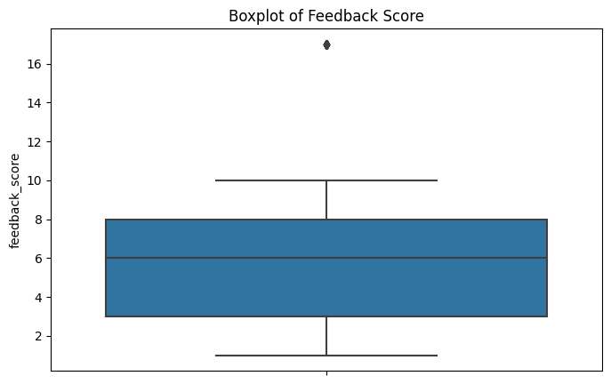

```
Sample Feedback Score Outliers:
```

|  | user_id | resource_type | usage_hours | resource_size | performance_score | region | cost | feedback_score | ticket_count | upgraded |
| --- | --- | --- | --- | --- | --- | --- | --- | --- | --- | --- |
| 48 | 49 | storage | NaN | 5TB | 88 | Europe | 10.255376 | 17 | 7 | True |
| 103 | 104 | storage | 222.0 | 5TB | 88 | Europe | 2.983871 | 17 | 4 | False |
| 111 | 112 | network | 162.0 | 1Gbps | 87 | North America | 6.532258 | 17 | 2 | False |
| 123 | 124 | network | NaN | 1Gbps | 83 | Asia | 30.927419 | 17 | 8 | True |
| 144 | 145 | database | 182.0 | 200GB | 82 | South America | 9.784946 | 17 | 3 | False |

```python
# Replace such entries with NaN (or 744 if a max cap is preferred)
df['usage_hours'].where(df['usage_hours'] <= 744, inplace=True)

# 1b. Handling outliers in feedback_score column
# Visualize the distribution of feedback_score
plt.figure(figsize=(8,5))
sns.boxplot(y=df['feedback_score'])
plt.title('Boxplot of Feedback Score')
plt.show()

# Compute IQR for feedback_score
Q1 = df['feedback_score'].quantile(0.25)
Q3 = df['feedback_score'].quantile(0.75)
IQR = Q3 - Q1

# Define bounds for outliers
lower_bound = Q1 - 1.5 * IQR
upper_bound = Q3 + 1.5 * IQR

# Print sample outliers
outliers = df[(df['feedback_score'] < lower_bound) | (df['feedback_score'] > upper_bound)]
print("Sample Feedback Score Outliers:")
outliers.head()
```

```python
# Replace outliers with median value (Alternative: Drop them or use other imputation methods)
median_feedback = df['feedback_score'].median()
df['feedback_score'] = df['feedback_score'].apply(lambda x: median_feedback if x < lower_bound or x > upper_bound else x)
```

## Question 2: **Probability and Statistics:**

- *Scenario:* In order to better allocate resources, you are asked to understand the distribution of `performance_score` across different `resource_types` in various `regions`.
  - What statistical tests or methods would you use to determine if there is a significant difference in `performance_score` between different `resource_types` in the same region?

**Hints:**

a. **Understanding Distribution of `performance_score`**:

- Begin by visually plotting the distribution of `performance_score` for different `resource_types` within each region.
- This will give a high-level view of the distribution patterns and if any apparent differences exist between the resources.

b. **Statistical Testing**:

- For this problem, one way to test if there's a significant difference in `performance_score` between different `resource_types` within the same region is using the Analysis of Variance (ANOVA). ANOVA is suited for comparing means across more than two groups. Here, the groups would be the different `resource_types`.
- Null Hypothesis (( H_0 )): All resource types have the same mean `performance_score` in a particular region.
- Alternative Hypothesis (( H_a )): At least one resource type has a different mean `performance_score` in that region.

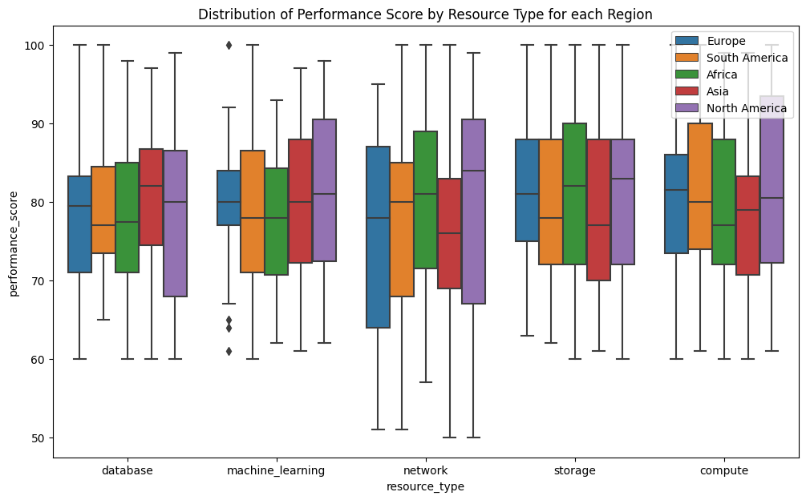

```
Region: Europe
F-statistic: 1.7423
P-value: 0.1426
Conclusion: There is no significant difference in performance_score between the resource types in this region.

Region: South America
F-statistic: 1.0614
P-value: 0.3768
Conclusion: There is no significant difference in performance_score between the resource types in this region.

Region: Africa
F-statistic: 0.5816
P-value: 0.6764
Conclusion: There is no significant difference in performance_score between the resource types in this region.

Region: Asia
F-statistic: 0.8475
P-value: 0.4965
Conclusion: There is no significant difference in performance_score between the resource types in this region.

Region: North America
F-statistic: 0.5151
P-value: 0.7247
Conclusion: There is no significant difference in performance_score between the resource types in this region.
```

```python
import pandas as pd
import matplotlib.pyplot as plt
import seaborn as sns
import scipy.stats as stats

df = df_Info_data.copy()

# 2a. Visualizing Distribution of performance_score
plt.figure(figsize=(12, 7))
sns.boxplot(data=df, x='resource_type', y='performance_score', hue='region')
plt.title('Distribution of Performance Score by Resource Type for each Region')
plt.legend(loc='upper right')
plt.show()

# 2b. Statistical Testing using ANOVA
# We'll iterate over each region and apply the ANOVA test
unique_regions = df['region'].unique()

for region in unique_regions:
    df_region = df[df['region'] == region]
    list_of_scores = [df_region['performance_score'][df_region['resource_type'] == rtype].values for rtype in df_region['resource_type'].unique()]
    F, p = stats.f_oneway(*list_of_scores)

    print(f"Region: {region}")
    print(f"F-statistic: {F:.4f}")
    print(f"P-value: {p:.4f}")
    if p < 0.05:
        print("Conclusion: There is a significant difference in performance_score between the resource types in this region.\n")
    else:
        print("Conclusion: There is no significant difference in performance_score between the resource types in this region.\n")
```

## Question 3: **Machine Learning & Modeling:**

- *Scenario:* To improve upselling strategies, you've been tasked with creating a model that predicts whether a user is likely to upgrade their resources in the coming month based on their past interactions.
  - Identify and justify the most appropriate target variable from the data provided for this prediction task.
  - Describe how you'd set up a machine learning framework for this task, ensuring model robustness and avoiding overfitting.

**Hints and Explanation**

#### 1. Target Variable Identification:

From the provided data, the most appropriate target variable for predicting whether a user is likely to upgrade their resources in the coming month based on their past interactions is the `upgraded` feature. This is a Boolean variable indicating if the resource was upgraded in the past month. This makes it a binary classification problem where 'True' indicates an upgrade and 'False' indicates no upgrade.

#### 2. Machine Learning Framework:

Here's how I would set up a machine learning framework:

**a. Data Preprocessing:**

- Handle any missing values if they exist. Options include imputation, dropping rows/columns, etc.
- Convert categorical variables like `resource_type` and `region` into numerical format using One-Hot Encoding.
- Normalize or standardize continuous variables like `usage_hours`, `resource_size`, `performance_score`, etc. to bring them to the same scale.

**b. Data Splitting:**

- Split the data into a training set (70% or 80%) and a test set (30% or 20%). This allows us to train our model on one set of data and test its performance on unseen data.

**c. Model Selection:**  
For a binary classification task, I would start with:

- Logistic Regression: As a baseline model.
- Random Forest: It handles non-linearity well and provides feature importance.
- Gradient Boosted Trees (like XGBoost): Known for high performance in such tasks.

**d. Cross-Validation:**  
To ensure robustness and avoid overfitting:

- Implement k-fold cross-validation. This will train the model on different subsets of the data, giving a better understanding of the model's average performance.
- Regularization techniques can also be used, especially if using logistic regression.

**e. Model Evaluation:**

- Use metrics like accuracy, precision, recall, F1-score, and AUC-ROC to evaluate the model's performance on the test data.

**f. Hyperparameter Tuning:**

- Using techniques like grid search or random search with cross-validation to find the best set of hyperparameters for our model.

```python
df_Info_data.dtypes
```

```
user_id                int64
resource_type         object
usage_hours            int64
resource_size         object
performance_score      int64
region                object
cost                 float64
feedback_score         int64
ticket_count           int64
upgraded                bool
dtype: object
```

```python
import pandas as pd
from sklearn.model_selection import train_test_split
from sklearn.linear_model import LogisticRegression
from sklearn.metrics import classification_report
from sklearn.preprocessing import StandardScaler

# Making a copy of the original data
df_copy = df_Info_data.copy()

# Function to preprocess resource_size based on resource_type
def preprocess_resource_size(row):
    if 'GB' in row['resource_size']:
        return float(row['resource_size'].replace('GB', ''))
    elif 'TB' in row['resource_size']:
        return float(row['resource_size'].replace('TB', '')) * 1000  # converting TB to GB
    elif 'Mbps' in row['resource_size']:
        return float(row['resource_size'].replace('Mbps', ''))
    elif 'Gbps' in row['resource_size']:
        return float(row['resource_size'].replace('Gbps', '')) * 1000  # converting Gbps to Mbps
    elif 'vCPUs' in row['resource_size']:
        return float(row['resource_size'].replace('vCPUs', ''))
    else:
        return 0

df_copy['resource_size'] = df_copy.apply(preprocess_resource_size, axis=1)

# Dropping 'user_id'
df_copy.drop('user_id', axis=1, inplace=True)

# One-Hot Encoding for 'resource_type' and 'region'
df_copy = pd.get_dummies(df_copy, columns=['resource_type', 'region'])

# Convert 'upgraded' to integer type
df_copy['upgraded'] = df_copy['upgraded'].astype(int)

# Splitting data
X = df_copy.drop('upgraded', axis=1)
y = df_copy['upgraded']

X_train, X_test, y_train, y_test = train_test_split(X, y, test_size=0.2, random_state=42)

# Standardize the features
scaler = StandardScaler()
X_train = scaler.fit_transform(X_train)
X_test = scaler.transform(X_test)

# Modeling with Logistic Regression
model = LogisticRegression()
model.fit(X_train, y_train)

predictions = model.predict(X_test)
print(classification_report(y_test, predictions))
```

```
              precision    recall  f1-score   support

           0       0.84      0.89      0.86       126
           1       0.79      0.72      0.75        74

    accuracy                           0.82       200
   macro avg       0.82      0.80      0.81       200
weighted avg       0.82      0.82      0.82       200
```

## Question 4: **Advanced Techniques:**

- *Scenario:* In the context of cloud infrastructure, understanding sequences of user actions can be crucial. You're interested in understanding patterns in ticket raising by users - especially if they follow any upgrades.
  - Propose a method or technique to analyze sequential patterns in user ticket raising behavior following any upgrades. This should take into account both `upgraded` and `ticket_count` columns.

**Roadmap for Analyzing Sequential Patterns in Ticket Raising Behavior Following Upgrades:**

1. **Data Preprocessing**:
   - Filter out rows where `ticket_count` is zero, as these do not add value to the sequential analysis of ticket raising behavior.
   - Sort data by `user_id` and some timestamp (assuming the data is already ordered chronologically for each user).
2. **Pattern Identification**:
   - For each user, create a sequence of events such as 'Upgraded' or 'Ticket Raised'.
   - Compute the frequency of each sequence within the entire dataset.
3. **Analysis & Visualization**:
   - Use frequency plots or bar graphs to display the most common sequences of events.
   - Focus especially on sequences that start with 'Upgraded' to understand the behavior post-upgrade.

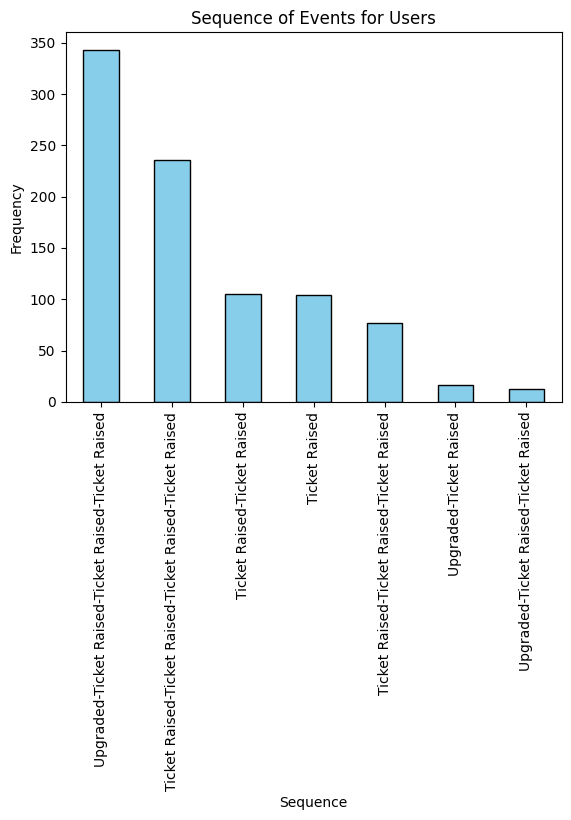

```python
import pandas as pd
import matplotlib.pyplot as plt

# Step 1: Data Preprocessing
df_filtered = df_Info_data[df_Info_data['ticket_count'] > 0].copy()

# Step 2: Pattern Identification
def generate_sequence(row):
    sequence = []
    if row['upgraded']:
        sequence.append('Upgraded')
    for _ in range(min(row['ticket_count'], 4-len(sequence))):
        sequence.append('Ticket Raised')
    return '-'.join(sequence)

df_filtered['sequence'] = df_filtered.apply(generate_sequence, axis=1)

sequence_counts = df_filtered['sequence'].value_counts()

# Step 3: Analysis & Visualization
sequence_counts.plot(kind='bar', color='skyblue', edgecolor='black')
plt.title('Sequence of Events for Users')
plt.ylabel('Frequency')
plt.xlabel('Sequence')
plt.show()
```